# lab3

```python
import matplotlib.pyplot as plt
```

## 1. Toss two coins

#### 1.1. Explain which object(s) are you flipping, and if you had two of these or just a single object.

I am tossing two quarters

#### 1.2. Toss the coins (or whatever object you chose). For each toss, add a row in the table about the number of heads in each trial.

| Trial | Heads |
| --- | --- |
| 1 | 0 |
| 2 | 1 |
| 3 | 1 |
| 4 | 0 |
| 5 | 0 |
| 6 | 2 |
| 7 | 1 |
| 8 | 2 |
| 9 | 0 |
| 10 | 0 |
| 11 | 0 |
| 12 | 1 |
| 13 | 1 |
| 14 | 1 |
| 15 | 1 |
| 16 | 1 |
| 17 | 2 |
| 18 | 0 |
| 19 | 1 |
| 20 | 2 |

#### 1.3. Show a summary of your results: how many times did you get 0 heads, 1 hears, 2 heads.

| Results | Time |
| --- | --- |
| 0 heads | 7 |
| 1 heads | 9 |
| 2 heads | 4 |

#### 1.4. Compute the mean of your results (the number of the heads you got)

```python
((7 * 0) + (9 * 1) + (4 * 2)) / 20
```

```
0.85
```

The mean is 0.85

#### 1.5. Compute the median (do not use the “median” function). Explain how do you do it.

0, 0, 0, 0, 0, 0, 0, 1, 1, 1, 1, 1, 1, 1, 1, 1, 2, 2, 2, 2

The median is between the 10th & 11th value, which means I take the average of the 10th value and 11th value. This comes out to be (1 + 1)/2, which is 1

#### 1.6. Compute the variance of your results (the number of heads in your individual trials).

variance is var X = mean(X^2) - mean(X)^2  
mean(X^2) = ((7 *0) + (9* 1) + (4 * 4)) / 20 = 1.25  
mean(X)^2 = 0.85^2 = 0.7225  
Variance = 1.25 - 0.7225 = 0.5275

#### 1.7. Compute standard deviation of your results

Standard deviation is sqrt(variance)  
Which is sqrt(0.5275) = 0.7263

#### 1.8. Plot (or manually sketch) a histogram of your results.

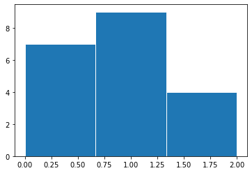

```python
results = [0, 0, 0, 0, 0, 0, 0, 1, 1, 1, 1, 1, 1, 1, 1, 1, 2, 2, 2, 2]
hist = plt.hist(results, bins = 3, edgecolor="w")
```

#### 1.10. Compute 20th percentile of your results

20th percentile = 0.2 * 20 = 4, which is 0. This is done ordering the numbers from smallest to largest then by multiplying 20% by the number of observations to get the index and then selecting the number that corresponds with the index.

#### 1.11. Compute 80th percentile of the results.

20th percentile = 0.8 * 20 = 16, which is 1. This is done ordering the numbers from smallest to largest then by multiplying 80% by the number of observations to get the index and then selecting the number that corresponds with the index.

The QSR is calulated by taking the sum of the top 20% which would be index 17-20, and then dividing it by the sum of the bottom 20% which would be index 1-4, this would result in 8/0, which is undefined. We can't find the QSR which is how many times more the top 20% have over the bottom 20% because the bottom 20% has nothing, which results in an undefined value.